# Informe Hito 1

# Exploración de datos

```r
# ajustar ubicación del archivo!!
datos_raw <- read.csv("datos/mineduc/rendimiento_escolar/2020.csv", sep = ";",
                        dec = ",", as.is = FALSE,
                        colClasses = c(
                          "integer",
                          rep("factor", 21), #NOM_RBD a COD_DES_CUR
                          "numeric", # MRUN
                          "factor", #GEN_ALU
                          "integer", #FEC_NAC_ALU
                          "integer", #EDAD_ALU
                          rep("factor", 6), #COD_REG_ALU a COD_ESPE
                          rep("numeric", 2), #PROM_GRAL, ASISTENCIA
                          rep("factor", 3)#SIT_FIN;SIT_FIN_R;COD_MEN
                        ))
```

```r
# decodificación
datos <- datos_raw

levels(datos$GEN_ALU) <- c("S/I", "HOMBRE", "MUJER")

levels(datos$RURAL_RBD) <- c("URBANO", "RURAL")

levels(datos$COD_DEPE) <- c("CORP_MUNICIPAL",
                            "MUNICIPAL_DAEM",
                            "PARTICULAR_SUBVEN",
                            "PARTICULAR_PAGADO",
                            "CORP_ADMIN_DELEGD",
                            "SERVI_LOCAL_EDUCA")

levels(datos$ESTADO_ESTAB) <- c("FUNCIONANDO",
                                "RECESO",
                                "CERRADO",
                                "AUTO_SIN_MAT")

levels(datos$SIT_FIN) <- c("SIN_INFO", "PROMOVIDO", "REPROBADO", "RETIRADO")

levels(datos$SIT_FIN_R) <- c(levels(datos$SIT_FIN), "TRASLADADO")
```

El dataset abarca más de 3 millones de alumnos.

Datos generales:

```r
# dimensiones
dim(datos)
```

```
[1] 3164534      37
```

```r
# atributos
colnames(datos)
```

```
 [1] "AGNO"           "RBD"            "DGV_RBD"        "NOM_RBD"
 [5] "COD_REG_RBD"    "NOM_REG_RBD_A"  "COD_PRO_RBD"    "COD_COM_RBD"
 [9] "NOM_COM_RBD"    "COD_DEPROV_RBD" "NOM_DEPROV_RBD" "COD_DEPE"
[13] "COD_DEPE2"      "RURAL_RBD"      "ESTADO_ESTAB"   "COD_ENSE"
[17] "COD_ENSE2"      "COD_GRADO"      "LET_CUR"        "COD_JOR"
[21] "COD_TIP_CUR"    "COD_DES_CUR"    "MRUN"           "GEN_ALU"
[25] "FEC_NAC_ALU"    "EDAD_ALU"       "COD_REG_ALU"    "COD_COM_ALU"
[29] "NOM_COM_ALU"    "COD_RAMA"       "COD_SEC"        "COD_ESPE"
[33] "PROM_GRAL"      "ASISTENCIA"     "SIT_FIN"        "SIT_FIN_R"
[37] "COD_MEN"
```

Si bien hay muchas columnas, los datos que estas proveen pueden ser agrupados en menos categorías: - Identificación del alumno: edad, género, y lugar de residencia - Rendimiento del alumno: curso, promedio general y porcentaje de asistencia - Identificación del colegio: identificador único (RBD), ubicación, administración (municipal, particular subvencionado, etc.). - Tipo de enseñanza: técnico-profesional, científico-humanista, para adultos, etc.

## Completitud

```r
# Provincias
length(unique(datos$COD_PRO_RBD))
```

```
[1] 56
```

```r
# Comunas
length(unique(datos$COD_COM_RBD))
```

```
[1] 345
```

```r
# Establecimientos
length(unique(datos$RBD))
```

```
[1] 9040
```

Chile tiene 56 provincias y 346 comunas, es decir, hay una sola comuna para la cual no hay ningún establecimiento en los datos. Todo el resto del territorio debiese estar representado.

De una [fuente externa](https://www.bcn.cl/siit/estadisticasterritoriales//resultados-consulta?id=82491) se obtiene que en Chile existen 11342 establecimientos educacionales, de los cuales 9040 están presentes en los datos. No está claro por qué estos establecimientos están ausentes, pero es probable que sean aquellos con menor cantidad de estudiantes. En general, el dataset parece ser bastante completo.

## Datos faltantes

```r
colSums(is.na(datos))
```

[output not shown]

Aparentemente existen sólo datos faltantes en la columna de edad. Esto se debe a que las otras columnas son factores, y los datos faltantes pueden estar codificados de otro forma (como un string vacío, o un espacio en blanco).

```r
# situacion final desconocida
sum(datos$SIT_FIN_R == "SIN_INFO")
```

```
[1] 1197
```

```r
# sin info de género
sum(datos$GEN_ALU == "S/I")
```

```
[1] 5
```

```r
# sin edad
sum(is.na(datos$EDAD_ALU))
```

```
[1] 635
```

```r
# sin info de edad

# sin info de lugar de residencia
 sum(datos$COD_REG_ALU == "0" | datos$COD_COM_ALU == "0")
```

```
[1] 2
```

```r
 # alumnos retirados (promedio 0,0)
 sum(datos$PROM_GRAL == 0.0)
```

```
[1] 115617
```

Hay pocos datos faltantes. La categoría más significativa son los alumnos retirados, cuyo promedio está ingresado como 0,0. Todos estos casos pueden ser retirados del dataset.

```r
datos <- subset(datos, !is.na(EDAD_ALU) & PROM_GRAL != 0 & GEN_ALU != "S/I" & COD_REG_ALU != "0" & COD_COM_ALU != "0")

# remove factors not present
for (fct in  c("GEN_ALU", "COD_REG_ALU", "COD_COM_ALU", "SIT_FIN", "SIT_FIN_R")) {
  datos[, fct] <- factor(datos[, fct])
}
datos$COD_COM_RBD <- factor(datos$COD_COM_RBD, levels = levels(datos$COD_COM_ALU))
```

## Distribución

```r
summary(datos$NOM_REG_RBD_A)
```

```
  ANTOF   ARAUC   ATCMA     AYP   AYSEN    BBIO     COQ   LAGOS    LGBO     MAG
 113031  177909   56233   44742   20241  267049  145082  156317  164308   27251
  MAULE   NUBLE    RIOS      RM    TPCA   VALPO
 185731   81068   68975 1165338   67970  307095
```

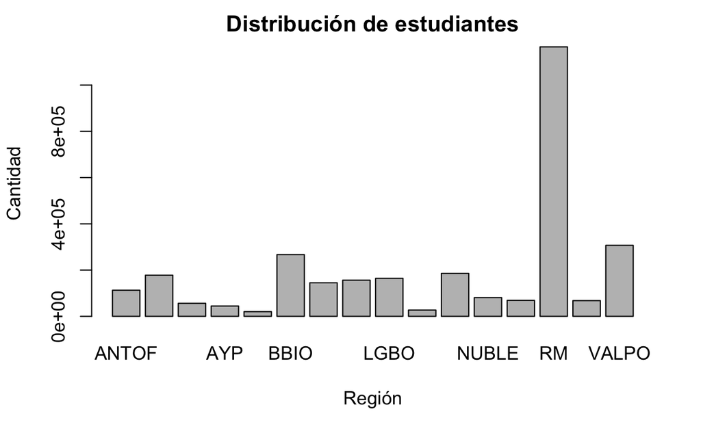

```r
Regiones = c("Antofagasta", "Araucanía", "Atacama", "Arica y Parinacota", "Aysén", "Biobío","Coquimbo", "Los Lagos", "O'higgins", "Magallanes", "Maule", "Ñuble", "Los Ríos", "RM", "Tarapacá", "Valparaíso")
plot(datos$NOM_REG_RBD_A, main = "Distribución de estudiantes", xlab = "Región", ylab = "Cantidad")
```

Como es esperable, la mayoría de los alumnos se concentran en la región metropolitana. Las regiones de Valparaíso y Bio Bio son las que mayor cantidad de alumnos tienen sin contar la metropolitana, mientras que Aysen y Magallanes tienen la menor cantidad.

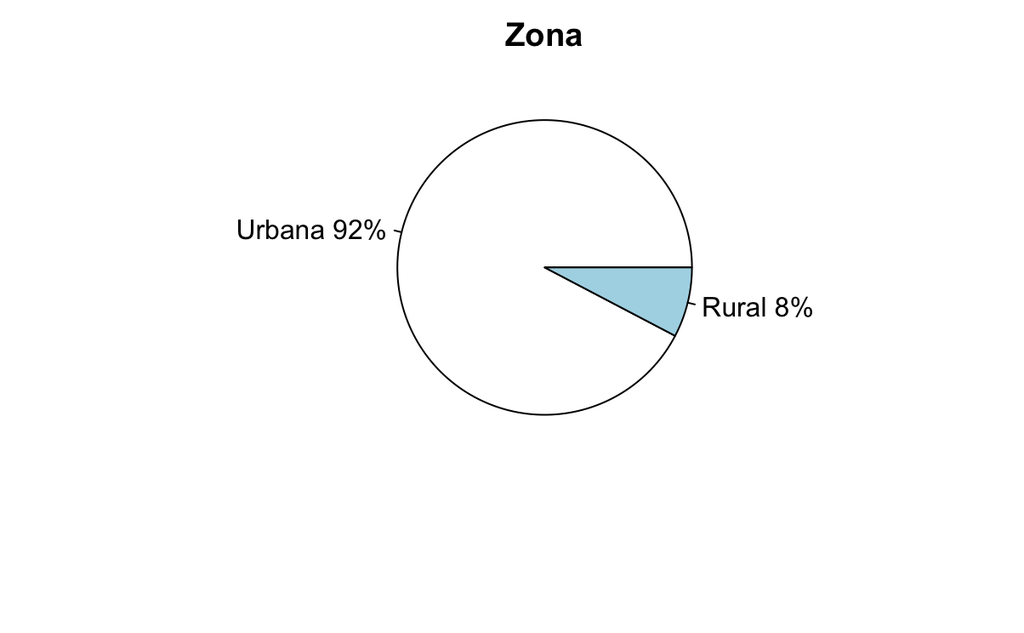

```r
pielabel = c("Urbana", "Rural")
pct <- round(summary(factor(datos$RURAL_RBD))/sum(summary(datos$RURAL_RBD))*100)
pielabel<-paste(pielabel, pct)
pielabel<-paste(pielabel, "%",sep="")
pie(table(datos$RURAL_RBD), labels = pielabel, main = "Zona")
```

Así mismo, la gran mayoría de los estudiantes se encuentran en zonas urbanas.

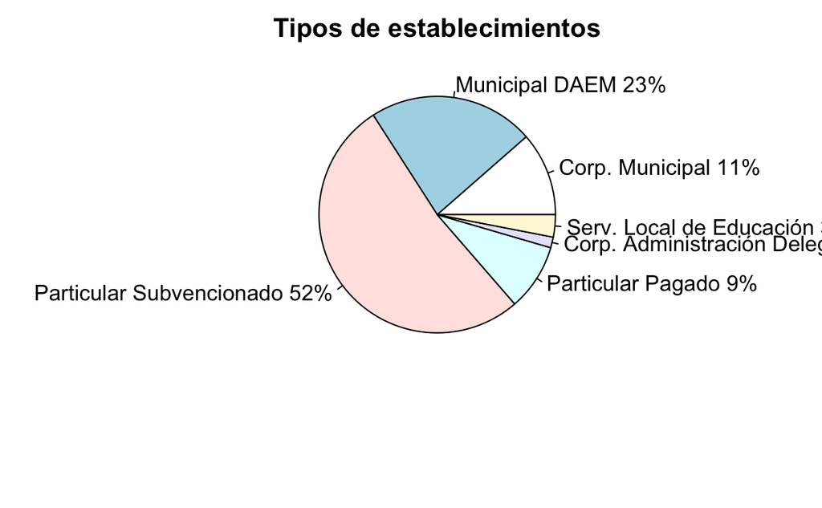

```r
pielabel = c("Corp. Municipal", "Municipal DAEM", "Particular Subvencionado", "Particular Pagado", "Corp. Administración Delegada", "Serv. Local de Educación")
pct <- round(summary(datos$COD_DEPE)/sum(summary(datos$COD_DEPE))*100)
pielabel<-paste(pielabel, pct)
pielabel<-paste(pielabel, "%",sep="")
pie(table(datos$COD_DEPE), labels = pielabel, main = "Tipos de establecimientos", )
```

Alrededor de la mitad de los estudiantes en Chile asiste a colegios particulares subvencionados. El servicio local de educación corresponde a un 3%, mientras que la corporación administración delegada corresponde al 1% del tipo de establecimientos del país.

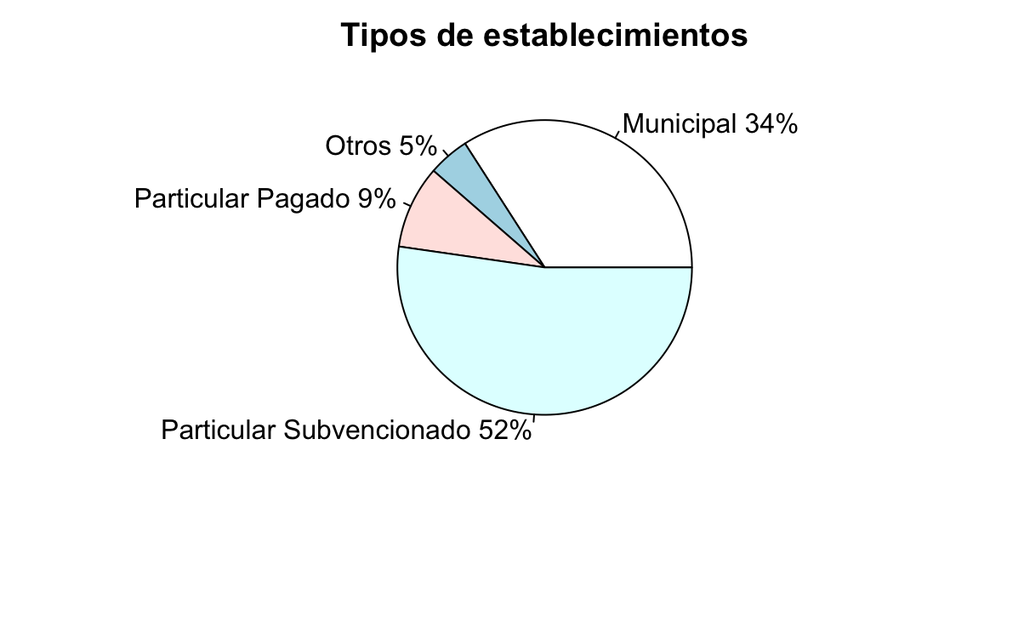

```r
testab<-datos
testab$COD_DEPE <-testab$COD_DEPE %>% str_replace_all(., "MUNICIPAL_DAEM", "MUNICIPAL")
testab$COD_DEPE <-testab$COD_DEPE %>% str_replace_all(., "CORP_MUNICIPAL", "MUNICIPAL")
testab$COD_DEPE <-testab$COD_DEPE %>% str_replace_all(., "SERVI_LOCAL_EDUCA", "OTROS")
testab$COD_DEPE <-testab$COD_DEPE %>% str_replace_all(., "CORP_ADMIN_DELEGD", "OTROS")
pielabel = c("Municipal", "Otros", "Particular Pagado", "Particular Subvencionado")
pct <- round(summary(factor(testab$COD_DEPE))/sum(summary(datos$COD_DEPE))*100)
pielabel<-paste(pielabel, pct)
pielabel<-paste(pielabel, "%",sep="")
pie(table(testab$COD_DEPE), labels = pielabel, main = "Tipos de establecimientos")
```

Esta visualización representa una forma más sencilla y común de ver la distribución de los tipos de establecimientos en Chile. Cabe notar que la diferencia entre los establecimientos administrados por corporaciones municipales y DAEM recae en el marco legislativo, por lo que agrupar ambas categorías no es un error, sino una simplificación.

```r
sum(is.na(datos$EDAD_ALU))
```

```
[1] 0
```

```r
length(datos[datos$EDAD_ALU == 0.0,]$EDAD_ALU)
```

```
[1] 0
```

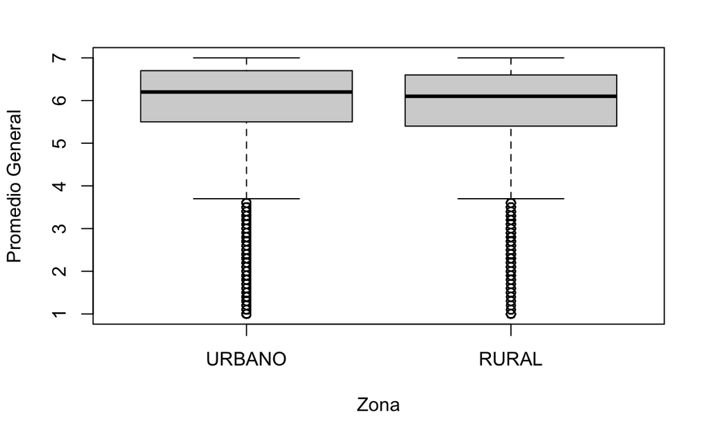

```r
boxplot(PROM_GRAL ~ RURAL_RBD, datos, ylab = "Promedio General", xlab = "Zona")
```

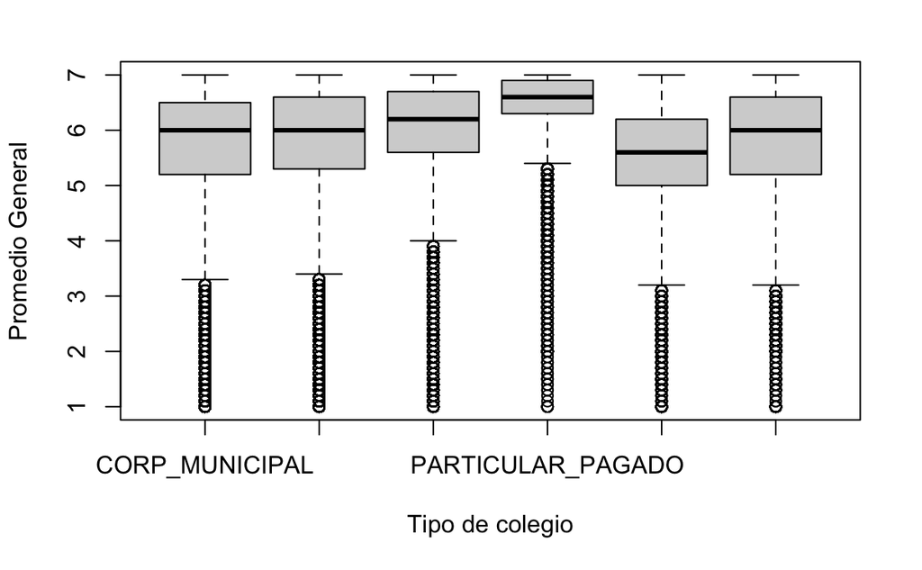

```r
boxplot(PROM_GRAL ~ COD_DEPE, datos, ylab = "Promedio General", xlab = "Tipo de colegio")
```

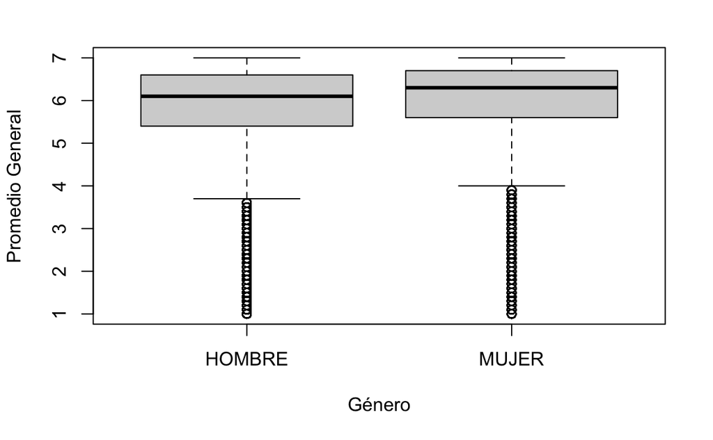

```r
boxplot(PROM_GRAL ~ GEN_ALU, datos, ylab = "Promedio General", xlab = "Género")
```

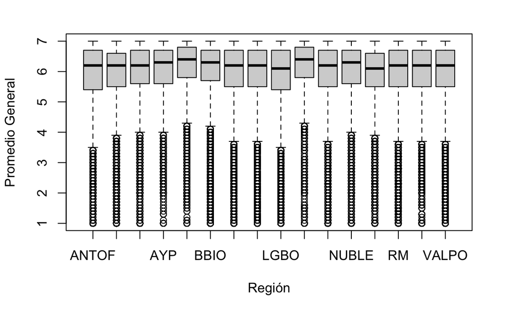

```r
boxplot(PROM_GRAL ~ NOM_REG_RBD_A, datos, ylab = "Promedio General", xlab = "Región")
```

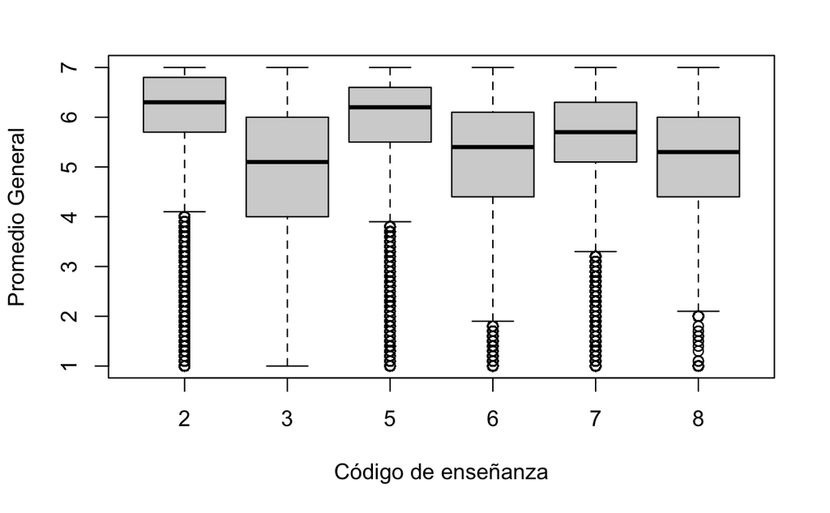

```r
boxplot(PROM_GRAL ~ COD_ENSE2, datos, ylab = "Promedio General", xlab = "Código de enseñanza")
```

Un criterio que arroja diferencias claras es el tipo de establecimiento, donde se observa una jerarquía con los colegios particulares pagados arriba, los sobvencionados en medio y los municipales abajo. El otro criterio es el nivel de enseñanza: los códigos 3, 6 y 8, que corresponden a educación para adultos, tienen una varianza mucho mayor y un promedio más bajo que la educación para jóvenes. Además, dentro de la educación para jóvenes se ve que la enseñanza técnico profesional tienen promedios más bajos que la humanistico científica.

Puesto que los datos de adultos tienen tanta varianza, se puede repetir el análisis considerando únicamente a los jóvenes.

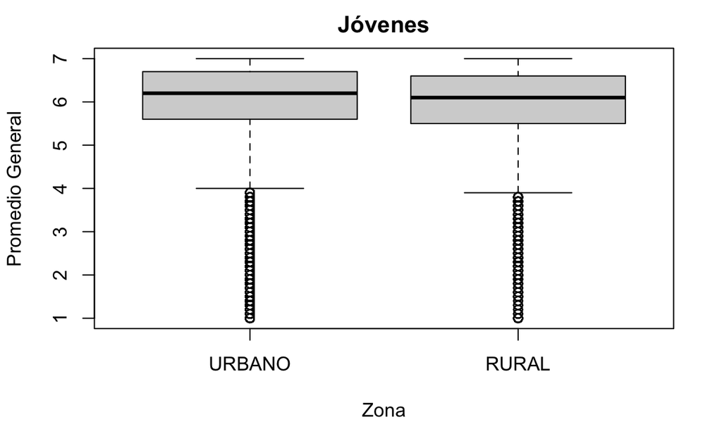

```r
cod_ense <- c("110", "210", "310", "410", "510", "610", "710", "810", "910")
jovenes <- datos[is.element(datos$COD_ENSE, cod_ense),]
jovenes$COD_ENSE <- factor(jovenes$COD_ENSE)

boxplot(PROM_GRAL ~ RURAL_RBD, jovenes, main = "Jóvenes", ylab = "Promedio General", xlab = "Zona")
```

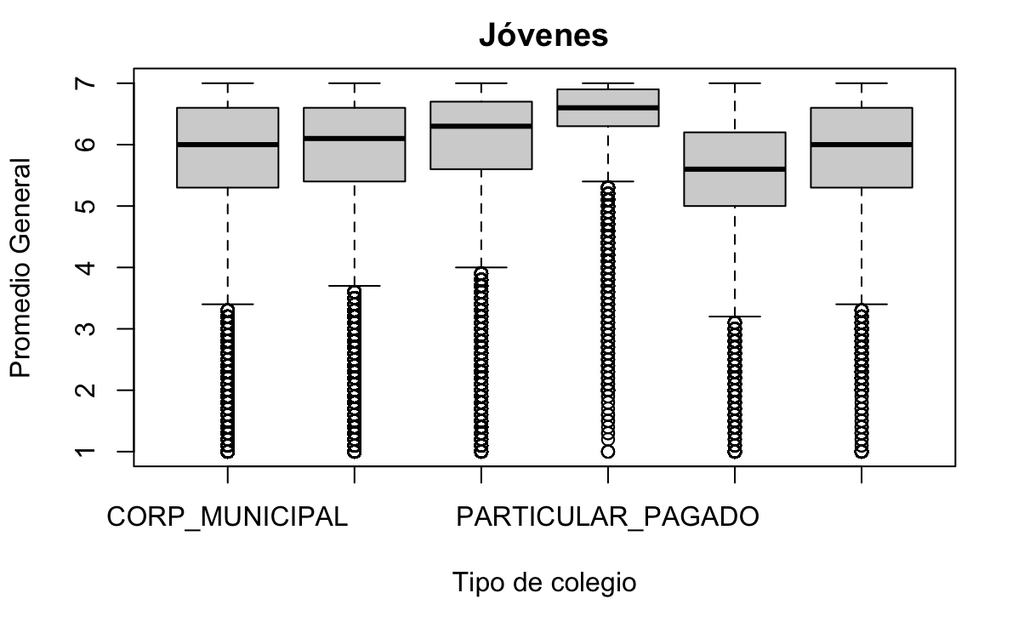

```r
boxplot(PROM_GRAL ~ COD_DEPE, jovenes, main = "Jóvenes", ylab = "Promedio General", xlab = "Tipo de colegio")
```

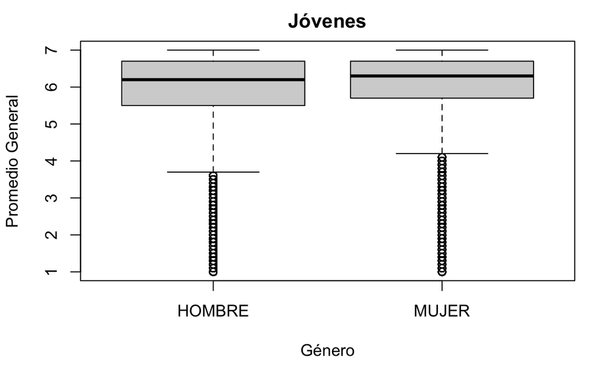

```r
boxplot(PROM_GRAL ~ GEN_ALU, jovenes, main = "Jóvenes", ylab = "Promedio General", xlab = "Género")
```

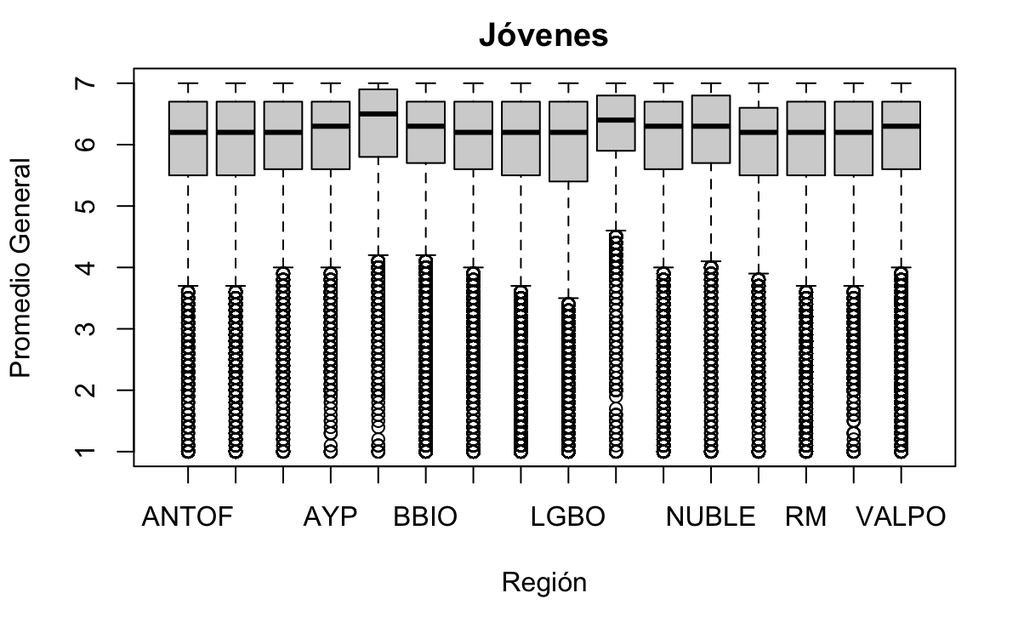

```r
boxplot(PROM_GRAL ~ NOM_REG_RBD_A, jovenes, main = "Jóvenes", ylab = "Promedio General", xlab = "Región")
```

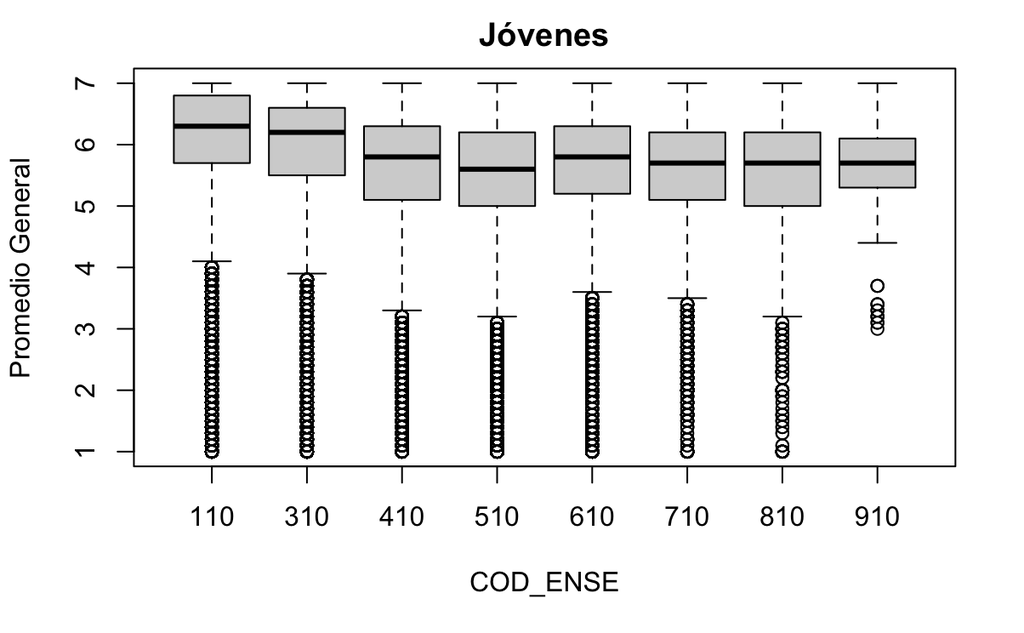

```r
boxplot(PROM_GRAL ~ COD_ENSE, jovenes, main = "Jóvenes", ylab = "Promedio General")
```

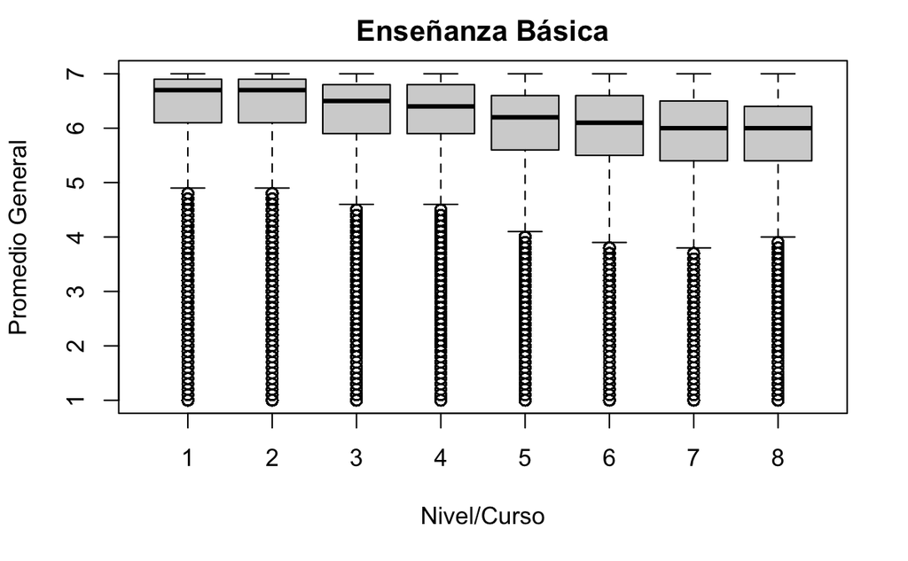

```r
# educacion básica
basica <- jovenes[jovenes$COD_ENSE == "110", ]
boxplot(PROM_GRAL ~ COD_GRADO, basica, main = "Enseñanza Básica", ylab = "Promedio General", xlab = "Nivel/Curso")
```

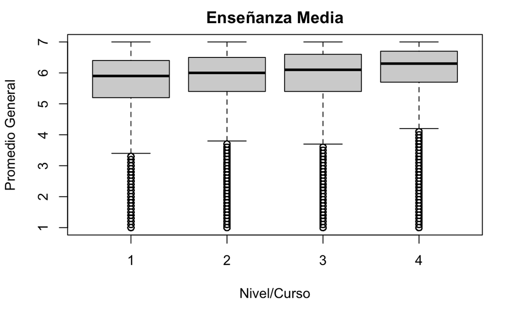

```r
# educación media
media <- jovenes[is.element(jovenes$COD_ENSE, cod_ense[2:length(cod_ense)]),]
media$COD_GRADO <- factor(media$COD_GRADO)
media$COD_ENSE <- factor(media$COD_ENSE)
boxplot(PROM_GRAL ~ COD_GRADO, media, main = "Enseñanza Media", ylab = "Promedio General", xlab = "Nivel/Curso")
```

Como es de esperarse dado los jóvenes son la mayoría de los estudiantes, la tendencia general se mantienen, con la excepción en el caso de los promedios por región, donde las diferencias se hacen más evidentes. Observando los promedios por curso se observa que tiende a descender en los cursos superiores, pero en la media la tendencia es la inversa.

Este análisis no revela patrones demasiado evidentes. De todos modos, puesto que los colegios no necesariamente evalúan con el mismo estándar de notas, no está claro que tan comparables son las notas de alumnos que asisten a colegios distintos. En este sentio, podría ser útil hacer comparaciones entre alumnos del mismo colegio. Por ejemplo: comparar resultados de alumnos que estudian en la misma comuna donde viven con los de alumnos que estudian en colegios de otras comunas.

```
[1] 2215148
[1] 708430
```

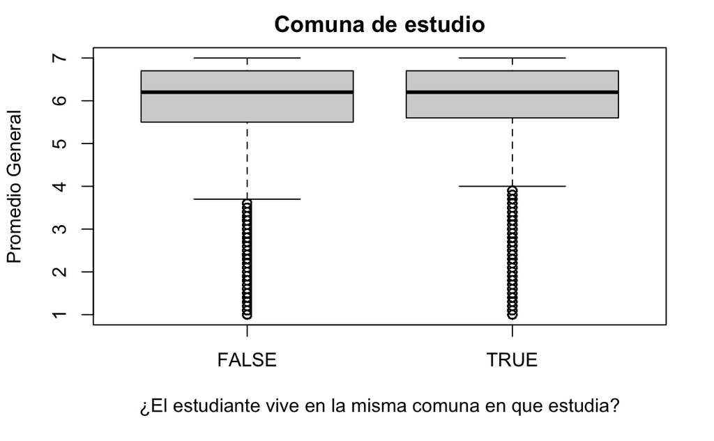

```r
with(jovenes,
     {
       jovenes$MISMA_COM <- (jovenes$COD_COM_RBD == jovenes$COD_COM_ALU)
       boxplot(PROM_GRAL ~ MISMA_COM, jovenes, main = "Comuna de estudio", ylab = "Promedio General", xlab = "¿El estudiante vive en la misma comuna en que estudia?")
       print(sum(jovenes$MISMA_COM))
       print(sum(!jovenes$MISMA_COM))
     })
```

El promedio general de quienes estudian en la misma comuna en la que viven parece ser un poco mayor, aunque la cantidad de alumnos en esta categoría es tres veces mayor a quienes estudian en comunas diferentes.